# tarea2

Grupo #8

2026-02-24

## Cargar librerías

```r
library(dplyr)
library(tidyr)
library(Matrix)
library(ggplot2)
library(Rtsne)
library(umap)
library(edfReader)
library(fastICA)
```

## Cargar el dataset

El archivo `u.data` contiene los ratings en formato:

user_id | item_id | rating | timestamp

```r
ratings <- read.table("data/u.data",
                      sep = "\t",
                      header = FALSE)

colnames(ratings) <- c("user_id", "item_id", "rating", "timestamp")

head(ratings)
```

```
##   user_id item_id rating timestamp
## 1     196     242      3 881250949
## 2     186     302      3 891717742
## 3      22     377      1 878887116
## 4     244      51      2 880606923
## 5     166     346      1 886397596
## 6     298     474      4 884182806
```

```r
dim(ratings)
```

```
## [1] 100000      4
```

## Construcción de la matriz Usuario × Película

Para aplicar SVD es necesario convertir los datos en una matriz donde:

- Filas → usuarios
- Columnas → películas
- Valores → ratings

```r
rating_matrix <- ratings %>%
  select(user_id, item_id, rating) %>%
  pivot_wider(names_from = item_id,
              values_from = rating,
              values_fill = 0)

user_ids <- rating_matrix$user_id

rating_matrix <- as.matrix(rating_matrix[,-1])

dim(rating_matrix)
```

```
## [1]  943 1682
```

## Aplicación de SVD

```r
svd_result <- svd(rating_matrix)

str(svd_result)
```

```
## List of 3
##  $ d: num [1:943] 641 245 218 159 158 ...
##  $ u: num [1:943, 1:943] 0.00853 0.01678 0.03319 0.05149 0.00376 ...
##  $ v: num [1:1682, 1:943] 0.01714 0.05084 0.00232 0.02539 0.02081 ...
```

El resultado contiene:

- U → factores asociados a usuarios
- D → valores singulares (importancia de componentes)
- V → factores asociados a películas

## Visualización de valores singulares

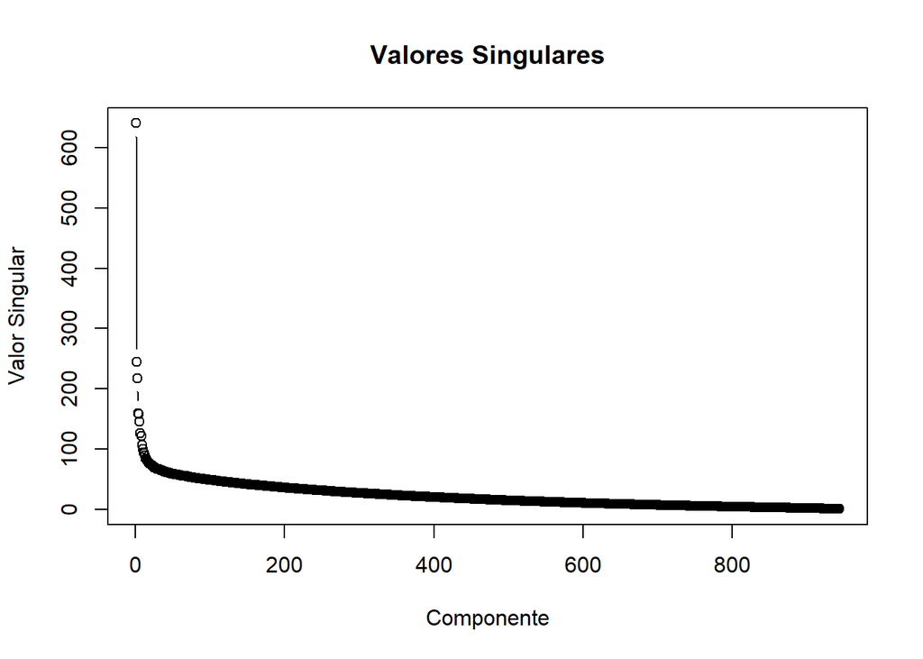

```r
plot(svd_result$d,
     type = "b",
     main = "Valores Singulares",
     xlab = "Componente",
     ylab = "Valor Singular")
```

Los primeros valores singulares concentran mayor información.

## Varianza explicada

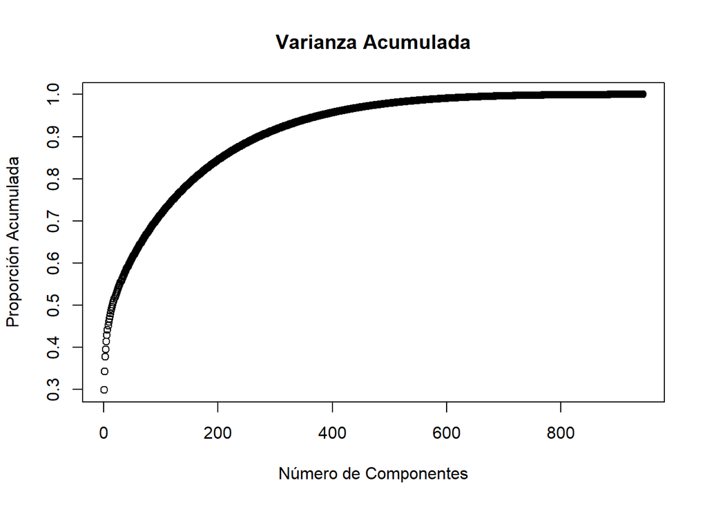

```r
variance_explained <- svd_result$d^2 / sum(svd_result$d^2)

plot(cumsum(variance_explained),
     type = "b",
     main = "Varianza Acumulada",
     xlab = "Número de Componentes",
     ylab = "Proporción Acumulada")
```

```r
# ¿Cuántos componentes explican 80% y 90%?

components_80 <- which(cumsum(variance_explained) >= 0.80)[1]
components_90 <- which(cumsum(variance_explained) >= 0.90)[1]

components_80
```

```
## [1] 159
```

```r
components_90
```

```
## [1] 272
```

Esta gráfica permite identificar cuántos componentes explican la mayor parte de la variabilidad del sistema.

## Reducción de dimensionalidad (SVD truncado)

Seleccionamos k componentes principales.

```r
k <- 20

U_k <- svd_result$u[,1:k]
D_k <- diag(svd_result$d[1:k])
V_k <- svd_result$v[,1:k]

approx_matrix <- U_k %*% D_k %*% t(V_k)

dim(approx_matrix)
```

```
## [1]  943 1682
```

## Error de reconstrucción

```r
reconstruction_error <- norm(rating_matrix - approx_matrix, type = "F")

reconstruction_error
```

```
## [1] 812.8734
```

Un menor error indica mejor aproximación usando k componentes.

## Comparación parcial

```r
original_sample <- rating_matrix[1:5,1:5]
approx_sample <- approx_matrix[1:5,1:5]

original_sample
```

```
##      242 302 377 51 346
## [1,]   3   0   0  0   0
## [2,]   0   3   0  0   0
## [3,]   0   0   1  0   0
## [4,]   0   0   0  2   0
## [5,]   0   0   0  0   1
```

```r
approx_sample
```

```
##            [,1]       [,2]         [,3]         [,4]        [,5]
## [1,]  0.7812385  0.9246899  0.028632014  0.053027436  0.02573357
## [2,]  0.4013566  1.0595446  0.020533813  0.367327869  0.24444772
## [3,]  0.2933030  0.2532724  0.090011330 -0.130733185 -0.10310155
## [4,] -0.3766809 -0.8599377 -0.005875941  2.191204870  0.15378501
## [5,] -0.0871198  1.5710042  0.005971020  0.002561477  0.54427996
```

## Interpretación de resultados

Al reconstruir la matriz utilizando solo 20 componentes, se obtiene un error de reconstrucción moderado. Esto indica que existe cierta pérdida de información, pero la estructura general del sistema de ratings se mantiene. Esto demuestra que el comportamiento de los usuarios puede representarse mediante factores latentes que resumen patrones de preferencia.

## Cargar dataset

```r
data <- read.csv("data/data.csv")

head(data)
```

```
##         id diagnosis radius_mean texture_mean perimeter_mean area_mean
## 1   842302         M       17.99        10.38         122.80    1001.0
## 2   842517         M       20.57        17.77         132.90    1326.0
## 3 84300903         M       19.69        21.25         130.00    1203.0
## 4 84348301         M       11.42        20.38          77.58     386.1
## 5 84358402         M       20.29        14.34         135.10    1297.0
## 6   843786         M       12.45        15.70          82.57     477.1
##   smoothness_mean compactness_mean concavity_mean concave.points_mean
## 1         0.11840          0.27760         0.3001             0.14710
## 2         0.08474          0.07864         0.0869             0.07017
## 3         0.10960          0.15990         0.1974             0.12790
## 4         0.14250          0.28390         0.2414             0.10520
## 5         0.10030          0.13280         0.1980             0.10430
## 6         0.12780          0.17000         0.1578             0.08089
##   symmetry_mean fractal_dimension_mean radius_se texture_se perimeter_se
```

[output cut: 34 more lines]

```r
dim(data)
```

```
## [1] 569  33
```

## Limpieza de datos

Eliminamos columnas que no aportan información al modelo.

```r
# Ver nombres de columnas
colnames(data)
```

```
##  [1] "id"                      "diagnosis"
##  [3] "radius_mean"             "texture_mean"
##  [5] "perimeter_mean"          "area_mean"
##  [7] "smoothness_mean"         "compactness_mean"
##  [9] "concavity_mean"          "concave.points_mean"
## [11] "symmetry_mean"           "fractal_dimension_mean"
## [13] "radius_se"               "texture_se"
## [15] "perimeter_se"            "area_se"
## [17] "smoothness_se"           "compactness_se"
## [19] "concavity_se"            "concave.points_se"
## [21] "symmetry_se"             "fractal_dimension_se"
## [23] "radius_worst"            "texture_worst"
## [25] "perimeter_worst"         "area_worst"
## [27] "smoothness_worst"        "compactness_worst"
## [29] "concavity_worst"         "concave.points_worst"
## [31] "symmetry_worst"          "fractal_dimension_worst"
## [33] "X"
```

```r
# Eliminar columna id
data <- data %>%
  select(-id)

# Eliminar columnas completamente vacías (si existen)
data <- data[, colSums(is.na(data)) < nrow(data)]
diagnosis <- data$diagnosis

data_numeric <- data %>%
  select(-diagnosis)
```

## Escalamiento de datos

```r
data_scaled <- scale(data_numeric)
```

## Aplicación de t-SNE

```r
set.seed(123)

tsne_result <- Rtsne(data_scaled,
                     dims = 2,
                     perplexity = 30,
                     verbose = TRUE,
                     max_iter = 500)
```

```
## Performing PCA
## Read the 569 x 30 data matrix successfully!
## OpenMP is working. 1 threads.
## Using no_dims = 2, perplexity = 30.000000, and theta = 0.500000
## Computing input similarities...
## Building tree...
## Done in 0.06 seconds (sparsity = 0.224116)!
## Learning embedding...
## Iteration 50: error is 62.155687 (50 iterations in 0.04 seconds)
## Iteration 100: error is 59.863724 (50 iterations in 0.03 seconds)
## Iteration 150: error is 59.867488 (50 iterations in 0.03 seconds)
## Iteration 200: error is 59.862841 (50 iterations in 0.02 seconds)
## Iteration 250: error is 59.865994 (50 iterations in 0.03 seconds)
## Iteration 300: error is 1.097055 (50 iterations in 0.03 seconds)
## Iteration 350: error is 1.023011 (50 iterations in 0.03 seconds)
## Iteration 400: error is 0.995339 (50 iterations in 0.03 seconds)
## Iteration 450: error is 0.989136 (50 iterations in 0.03 seconds)
## Iteration 500: error is 0.985254 (50 iterations in 0.03 seconds)
## Fitting performed in 0.28 seconds.
```

## Crear dataframe para visualización

```r
tsne_df <- data.frame(
  Dim1 = tsne_result$Y[,1],
  Dim2 = tsne_result$Y[,2],
  Diagnosis = diagnosis
)
```

## Visualización

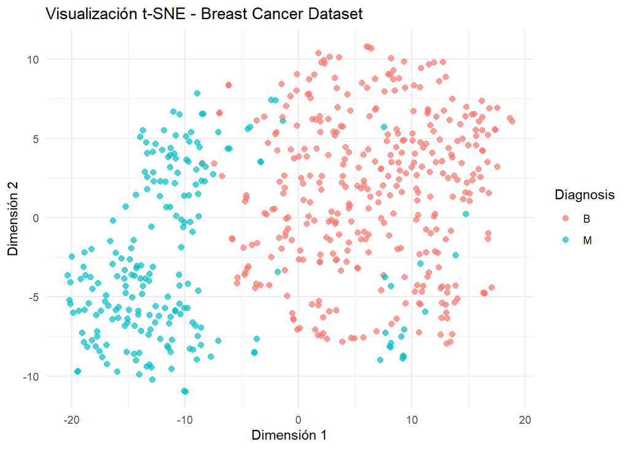

```r
ggplot(tsne_df, aes(x = Dim1, y = Dim2, color = Diagnosis)) +
  geom_point(size = 2, alpha = 0.7) +
  labs(title = "Visualización t-SNE - Breast Cancer Dataset",
       x = "Dimensión 1",
       y = "Dimensión 2") +
  theme_minimal()
```

## Interpretación de resultados

La visualización obtenida mediante t-SNE muestra una clara tendencia a la formación de dos grupos principales, correspondientes a los diagnósticos benigno (B) y maligno (M). Esto indica que las variables del dataset contienen información suficiente para diferenciar ambos tipos de tumores.

Se observa que los puntos malignos tienden a concentrarse en una región específica del espacio bidimensional, mientras que los benignos ocupan otra zona distinta. Aunque existe cierto solapamiento entre ambos grupos, la separación general es evidente.

Dado que t-SNE preserva relaciones locales entre observaciones, esta agrupación sugiere que los pacientes con características similares tienden a compartir el mismo diagnóstico. Esto demuestra la utilidad del algoritmo como herramienta de visualización para explorar la estructura interna de datos de alta dimensionalidad.

## Aplicación de UMAP

```r
set.seed(123)

umap_result <- umap(data_scaled)
```

## Crear dataframe para visualización

```r
umap_df <- data.frame(
  Dim1 = umap_result$layout[,1],
  Dim2 = umap_result$layout[,2],
  Diagnosis = diagnosis
)
```

## Visualización

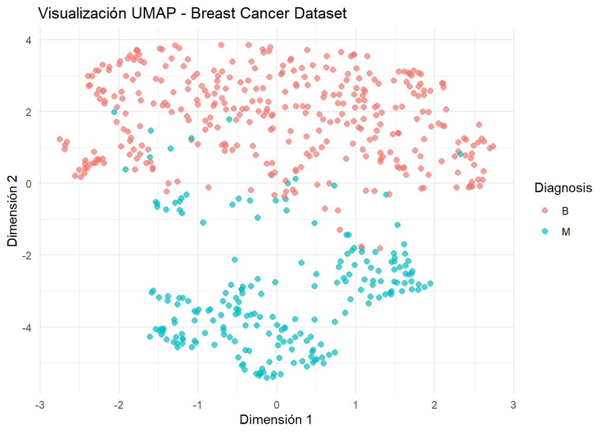

```r
ggplot(umap_df, aes(x = Dim1, y = Dim2, color = Diagnosis)) +
  geom_point(size = 2, alpha = 0.7) +
  labs(title = "Visualización UMAP - Breast Cancer Dataset",
       x = "Dimensión 1",
       y = "Dimensión 2") +
  theme_minimal()
```

## Interpretación de resultados

La proyección obtenida mediante UMAP muestra una separación clara entre los casos benignos y malignos. A diferencia de t-SNE, UMAP tiende a preservar no solo las relaciones locales entre puntos, sino también parte de la estructura global del conjunto de datos.

En la visualización se observa que los dos grupos presentan menor solapamiento y una estructura más compacta, lo que sugiere que UMAP captura de forma eficiente la geometría interna de los datos.

Esto confirma que las características clínicas medidas en el dataset permiten diferenciar ambos diagnósticos y demuestra que UMAP es una herramienta efectiva para la reducción de dimensionalidad y visualización de datos complejos.

## Cargar señal ECG convertida

```r
ecg <- read.csv("data/100_ecg.csv")

dim(ecg)
```

```
## [1] 650000      2
```

```r
head(ecg)
```

```
##       X0     X1
## 1 -0.145 -0.065
## 2 -0.145 -0.065
## 3 -0.145 -0.065
## 4 -0.145 -0.065
## 5 -0.145 -0.065
## 6 -0.145 -0.065
```

## Seleccionar una porción de la señal

(Usamos solo las primeras 5000 muestras para simplificar el análisis)

```r
signals <- as.matrix(ecg[1:5000, ])

dim(signals)
```

```
## [1] 5000    2
```

## Visualizar señales originales

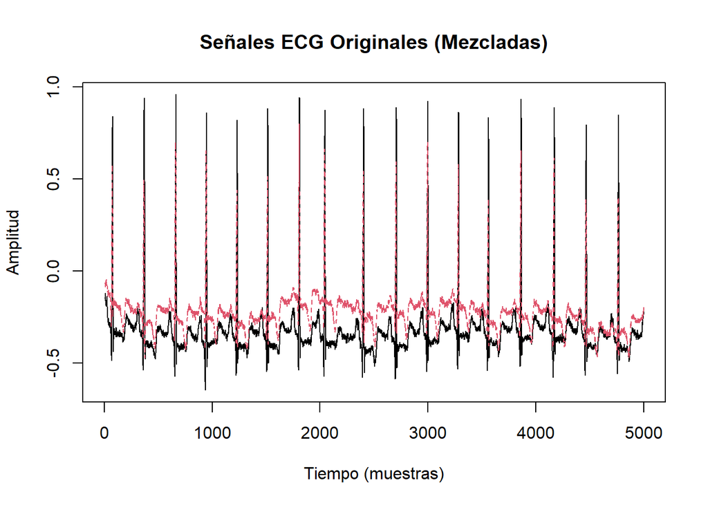

```r
matplot(signals, type="l",
        main="Señales ECG Originales (Mezcladas)",
        xlab="Tiempo (muestras)",
        ylab="Amplitud")
```

## Aplicar ICA

```r
set.seed(123)

ica_result <- fastICA(signals, n.comp = ncol(signals))

components <- ica_result$S

dim(components)
```

```
## [1] 5000    2
```

## Visualizar componentes independientes

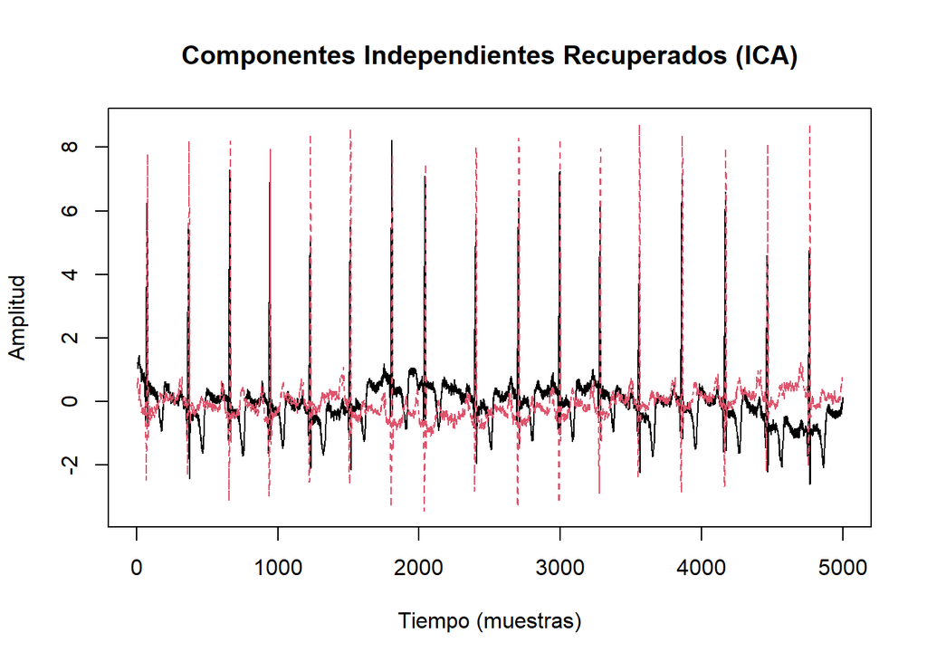

```r
matplot(components, type="l",
        main="Componentes Independientes Recuperados (ICA)",
        xlab="Tiempo (muestras)",
        ylab="Amplitud")
```

## Interpretación de resultados

Las señales ECG originales corresponden a registros reales del MIT-BIH Arrhythmia Database. Estas señales representan mediciones eléctricas cardíacas registradas mediante múltiples derivaciones, las cuales pueden contener mezclas de diferentes fuentes fisiológicas y posibles artefactos.

Al aplicar ICA, el algoritmo busca descomponer las señales observadas en componentes estadísticamente independientes. En la visualización de los componentes recuperados se observan patrones diferenciados, lo que indica que ICA logró separar parcialmente las fuentes subyacentes presentes en la señal original.

Este resultado demuestra la utilidad de ICA en el análisis de señales biomédicas, ya que permite identificar estructuras ocultas y separar posibles fuentes independientes a partir de mezclas lineales observadas.